# Stretch 02

Predicting Why Civil Servants Exit

Author

Benjamin Reese

## Setup

```r
## Packages
library(tidyverse)
library(tidymodels)
library(lubridate)
library(readr)
library(patchwork)
library(ggjoy)
library(vip)

## Data Loading
sep_data <- read.csv("data/SEPDATA_FY2005-2009.TXT")
load("~/Fall 2022/Data Science/stretch02/data/fed.RData")
app_data <- read_csv("data/EAD+2.0+quarter+101019.csv")
```

### (a)

#### Why Do Federal Employees Leave the Civil Service

The goal of my analysis is to create a classification model that can be used by the Office of Personnel Management to predict why and when employees quit.

For my data, I am joining three datasets together to create a new dataset with 13 variables and $955,322$ observations. The main dataset, that includes the target variable I want to predict is `sep_data`. This dataset includes information on nearly every federal employee, covering most non-intelligence community agencies, who left federal service from 2005-2009. This dataset can be found [here](https://www.opm.gov/data/index.aspx). The goal of this analysis is to predict why federal employees leave the federal workforce. I construct the target variable as only “quit” or “not quit” for simplicity. The other two datasets are for factors beyond what OPM tracks that may contribute to people leaving the federal workforce. The first of the supplementary datasets includes economic variables like inflation prepared by Mike Bailey for his introductory statistics textbook. It can be found [here](https://global.oup.com/us/companion.websites/9780199981946/stu/ch6/data_sets/). The second of the supplementary datasets was compiled by the Executive Approval Project and covers presidential approval. It can be found [here](http://www.executiveapproval.org/datasets-1/). The end result of the analysis will be a model that predicts why a civil servant quits versus leaving for another reason such as retirement or being fired.

Types of non-quitting civil servant exit such as retirements and Reductions In Force are mostly controllable or more easily predicted by agencies based on the age of their employees and their internal staffing decisions. Quitting, though, can seriously disrupt an agency’s functionality and is not as easily controlled or predictable by federal managers. Hopefully, this model will give some indication about why employees quit and show the important factors that predict quitting. In sum, this model hopes to answer the question: why do federal employees quit the civil service?

### Data Wrangling

The code below reads in the three datasets, creates some variables of interest and joins them all together.

```r
## Loading in data on when federal employees quit, creating education and quit variables
sep_data <- sep_data %>%
  mutate(quarter = str_replace_all(EFDATE, "(.{4})(.*)", "\\1-\\2"),
         quarter = quarter(ym(quarter), type = "year.quarter"),
         separation = if_else(SEP == "SC", "Quit", "Not Quit"),
         EDLVL = as.numeric(EDLVL)) %>%
  filter(!is.na(EDLVL) & EDLVL != "**")%>%
  mutate(education = case_when(
           EDLVL < 4 ~ "Less Than High School",
           EDLVL == 4 ~ "High School or GED",
           EDLVL == 5 | EDLVL == 6 | EDLVL == 7 | EDLVL == 8 | EDLVL == 9 |
           EDLVL == 10 | EDLVL == 11 | EDLVL == 12 ~ "Less than Bachelors",
           EDLVL == 13 ~ "Bachelors",
           EDLVL > 13 ~ "Graduate")) %>%
  select(separation, education, quarter, SALARY, LOS)

## dropping unused variables, creating a unified presidents and party variable, and filtering to only quarters
## included in the civil servant exit data
econ_data <- dta %>%
  select(-Democrat, -pres1, -pres2, -pres3, -pres4, -pres5, -pres6, -pres7,
         -pres8, -pres9, -pres10, -pres11, -pres12, -pres13, -pres14, -pres15) %>%
  mutate(admin = case_when(
    president == 1 ~ "Obama",
    president == 2 | president == 3 ~ "Eisenhower",
    president == 4 ~ "H.W. Bush",
    president == 5 | president == 6 ~ "W. Bush",
    president == 7 ~ "Carter",
    president == 8 ~ "Kennedy-Johnson",
    president == 9 ~ "Johnson",
    president == 10 ~ "Nixon-Ford",
    president == 11 ~ "Nixon",
    president == 12 | president == 13 ~ "Reagan",
    president == 14 | president == 15 ~ "Clinton"),
  party = case_when(
    president_party == 2 ~ "R",
    president_party == 1 ~ "D"),
  quarter = quarter(DATE,type = "year.quarter")) %>%
    select(-president, -president_party, -DATE, -ygap, -Quarters)

## filtering to only include the US, dropping unused variables and renaming
app_data <- app_data %>%
  filter(Country == "United States") %>%
  select(qtr, Approval_Smoothed) %>%
  mutate(approval = Approval_Smoothed,
    quarter = as.numeric(str_replace_all(qtr, 'q', "."))) %>%
  select(-Approval_Smoothed, -qtr)

## joining the three datasets all together into one unified tibble
sep <- sep_data %>%
  left_join(econ_data, by="quarter") %>%
  left_join(app_data, by = "quarter") %>%
  mutate(quarter = quarter(yq(quarter)),
         quarter = as.character(quarter)) %>%
  janitor::clean_names()
```

### (b)

```r
## Setting Seed
set.seed(20201124)

## Splitting the Sample
split <- initial_split(sep, prop = 0.7)

## Training and Testing
sep_train <- training(split)
sep_test <- testing(split)
```

### (c)

[figure not shown]

```r
## Displaying More Places In Numbers
options(scipen = 999999)

## Exploratory Data Analysis

## Line Plot of the # Employees Quitting
m2 <- sep_train %>%
  mutate(quarter = as.numeric(quarter)) %>%
  filter(separation == "Quit") %>%
  group_by(quarter) %>%
  count(separation=="Quit") %>%
  ggplot(aes(x=quarter, y=n)) +
  geom_line(lwd=1, col="light blue") +
    geom_point(col="blue") +
  theme_minimal() +
  labs(title = "When Civil Servants Exit",
       subtitle = "Federal Employees Quit Most in 3rd & 4th Quarters",
       x=NULL, y="# Quitting")

## Line Plot of the Percentage of Employees Leaving That Quit
m1 <- sep_train %>%
  mutate(separation = if_else(separation == "Quit", 1, 0),
         quarter = as.numeric(quarter)) %>%
  group_by(quarter) %>%
  summarise(percent_quit = mean(separation)) %>%
  mutate(percent_quit=percent_quit*100) %>%
  ggplot(aes(x=quarter, y=percent_quit)) +
  geom_line(lwd=1, col="light blue") +
   geom_point(col="blue") +
  theme_minimal() +
  lims(y=c(33,43))+
  labs(x="Fiscal Year Quarter", y="Percent Exits Who Quit",
       caption = "Data Source: Office of Personnel Management")
## Using patchwork to display together
m2 / m1
```

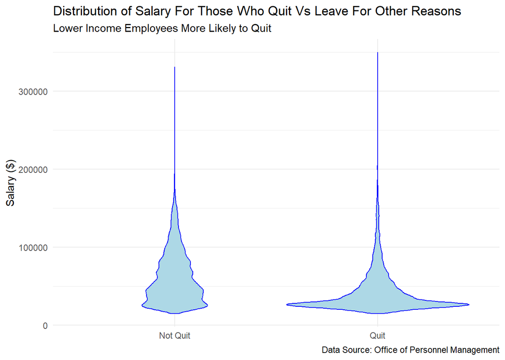

```r
## Relationship Between Salary And Quitting
sep_train %>%
  group_by(separation) %>%
  ggplot(aes(x=salary, y=separation)) +
  geom_violin(scale="area", col="blue", fill="light blue") +
  theme_minimal() +
  coord_flip() +
  labs(y=NULL, x="Salary ($)",
       title="Distribution of Salary For Those Who Quit Vs Leave For Other Reasons",
       subtitle = "Lower Income Employees More Likely to Quit",
       caption = "Data Source: Office of Personnel Management")
```

[figure not shown]

```r
## Relationship Between Presidential Approval And Quitting
sep_train %>%
  group_by(separation) %>%
  ggplot(aes(x=approval, y=separation, fill=separation)) +
  geom_joy() +
  theme_minimal() +
  labs(y=NULL, x="Approval Rating (%)",
       title="Presidential Approval and Federal Employee Exit",
       subtitle = "More Employees Quit When Presidential Approval Is Low",
       fill=NULL, caption = "Data Source: Office of Personnel Management")
```

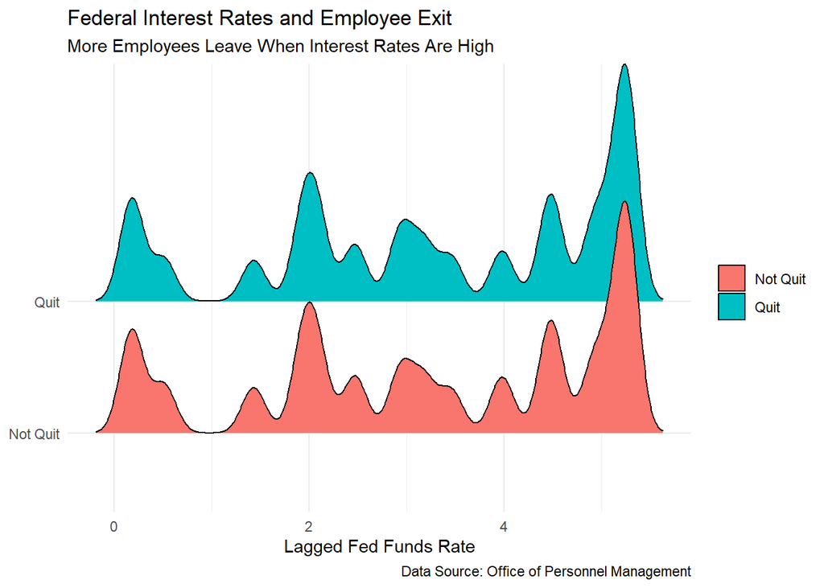

```r
## Relationship Between Fed Funds Rate And Quitting
sep_train %>%
  group_by(separation) %>%
  ggplot(aes(x=lag_fedfunds, y=separation, fill=separation)) +
  geom_joy() +
  theme_minimal() +
  labs(y=NULL, x="Lagged Fed Funds Rate",
       title="Federal Interest Rates and Employee Exit",
       subtitle = "More Employees Leave When Interest Rates Are High",
       fill=NULL, caption = "Data Source: Office of Personnel Management")
```

```r
## Party And Quitting
sep_train %>%
  mutate(separation = if_else(separation == "Quit", 1, 0)) %>%
  group_by(party) %>%
  summarise(percent_quit = mean(separation))
```

```
# A tibble: 2 × 2
  party percent_quit
  <chr>        <dbl>
1 D            0.374
2 R            0.386
```

The violin plot below the line graphs shows that the majority of quitters are in low income positions, meaning that people with higher pay, and probably more prestigious or professional occupations, are less likely to quit than lower-income employees.

Perhaps unexpectedly, federal employees do not seem to be more likely to quit when presidential approval rating is lower. As the president is the Chief Executive Officer of the federal bureaucracy, it could make sense that a disliked president will see more of their employees leaving than a liked president, but this is not the case. It is important to remember that this data is mostly only for 1 president, though: George W. Bush.

The second joyplot above uses the Federal Reserve Funds rate as a proxy for economic performance. The Fed Funds rate does not seem to influence decisions to quit or not. The full dataset includes variables for inflation, so it will be interesting to see how important other economic performance indicators are for predicting federal employee exit.

Finally, the table above shows that Republicans, in this case only George W. Bush, saw a higher percentage of employees leaving as quitters than Barack Obama.

### (d)

Overall, Accuracy and the Recall/Sensitivity/True Positive rate are the most important error metrics for this analysis because the goal is to accurately predict an event when it occurs. Incorrect predictions that an event will not occur when it does occur are the most costly form of error because not preparing for a large sudden civil servant exit could cause large efficiency losses in the federal service. Thus, a false negative is more damaging than a false positive. A false positive, or expecting a federal employee to quit, may still carry large costs if the prediction is so incorrect that it causes agencies to hire unneeded employees, but, overall, with the goal being to reduce uncertainty in the exiting of civil servants, false negatives are far more costly. In sum, the costs of false negatives, and a low sensitivity/recall makes the model less useful because it is not fulfilling its role in reducing uncertainty in federal employee exit. While I will select the best model based on overall accuracy, I will also evaluate the final model in terms of recall.

## Models

### (a)

I define here three candidate models with two different pre-processings. Their exact specifications are below.

The outcome variable to be classified is reason for separation, defined as “quit” or “not quit”, and it will be down-sampled in one pre-processing. The predictor variables are: level of education - which will be pre-processed into dummy variables; fiscal quarter - which will be pre-processed into dummy variables; employee salary - which will be normalized; the Federal Reserve Funds rate - which will be normalized; debt-to-GDP ratio - which will be normalized; expenditure-to-GDP ratio - which will be normalized; inflation - which will be normalized; presidential administration - which will be made into dummy variables; party of president - will also be made into dummy variables; and presidential approving rating - which will be normalized. Since there are a variety of different units and, for example, the salary and inflation variables are wildly skewed, all of these predictors need normalization during pre-processing. I will also drop variables without much variance. I will finally turn the character variables into dichotomous predictors for one of the recipes. The exact pre-processing for each recipe can be found below:

```r
## First Recipe
sep_rec_1 <-
  recipe(separation ~ ., data = sep_train) %>%
  themis::step_downsample(separation) %>%
  step_dummy(all_nominal_predictors()) %>%
  step_normalize(all_numeric_predictors()) %>%
  step_nzv(all_numeric_predictors())

## Second Recipe
sep_rec_2 <-
  recipe(separation ~ ., data = sep_train) %>%
  step_normalize(all_numeric_predictors()) %>%
  step_nzv(all_predictors())

## Setting up folds for cross-validation
folds <- vfold_cv(sep_train, folds=10)
```

The three candidate models considered here are a CART model, a logistic regression model, and a random forest model.

### CART Model Specification and Workflow

```r
## Creating the CART Model
cart_mod <-
  decision_tree() %>%
  set_engine(engine = "rpart") %>%
  set_mode(mode = "classification")

## CART Workflow
cart_wf <- workflow() %>%
  add_recipe(sep_rec_1) %>%
  add_model(cart_mod)
```

### Random Forest Model Specification and Workflow

```r
## Creating Grid for Hyperparameter Tuning
rf_grid <- grid_regular(
  mtry(range = c(10, 30)),
  min_n(range = c(2, 8)),
  levels = 5)

## Random Forest Model
rf_mod <- rand_forest(mtry = tune(), trees = 1000, min_n = tune()) %>%
  set_engine("ranger") %>%
  set_mode("classification")

## Random Forest Workflow
rf_wf <- workflow() %>%
  add_recipe(sep_rec_2) %>%
  add_model(rf_mod)

## Tuning Hyperparameters
rf_class <- rf_wf %>%
  tune_grid(tune_wf, resamples = folds, grid = rf_grid)
```

### Logisitic Regression Model Specification and Workflow

```r
## Creating the Logistic Regression Model
log_mod <-
  logistic_reg() %>%
  set_engine(engine = "glm") %>%
  set_mode(mode = "classification")

## Logistic Regression Workflow
log_wf <- workflow() %>%
  add_recipe(sep_rec_1) %>%
  add_model(log_mod)

## Estimating the Model
log_fit <- log_wf %>%
  fit_resamples(resamples = folds)
```

## 3

In this section, I implement the CART model above to try to predict the reasons why civil servants exit.

```r
## Creating the CART Model
cart_mod <-
  decision_tree() %>%
  set_engine(engine = "rpart") %>%
  set_mode(mode = "classification")

## CART Workflow
cart_wf <- workflow() %>%
  add_recipe(sep_rec_1) %>%
  add_model(cart_mod)

## Estimating the Model
cart_fit <- cart_wf %>%
  fit_resamples(resamples = folds)

## Selecting Best Model
cart_fit_best <- cart_fit %>%
  select_best(cart_fit, metric = "accuracy")

## Finalizing Workflow for Best Model
cart_final <- cart_wf %>%
  tune::finalize_workflow(cart_fit_best) %>%
  parsnip::fit(data = sep_train)
```

## 4

In this section, I generate a confusion matrix, find the accuracy, find the recall, and visualize the results with a decision tree in order to interpret the effectiveness of the model.

```r
## The Predictions
predictions <- bind_cols(
  sep_test,
  predict(object = cart_final, new_data = sep_test),
  predict(object = cart_final, new_data = sep_test, type = "prob")
) %>%
  mutate(separation = as.factor(separation))

## The Predictions
select(predictions, separation, starts_with(".pred")) %>%
  slice(1:30)
```

```
   separation .pred_class .pred_Not Quit .pred_Quit
1    Not Quit        Quit      0.3312008 0.66879920
2    Not Quit        Quit      0.3312008 0.66879920
3    Not Quit        Quit      0.3312008 0.66879920
4    Not Quit        Quit      0.3312008 0.66879920
5        Quit        Quit      0.3312008 0.66879920
6    Not Quit        Quit      0.3312008 0.66879920
7    Not Quit        Quit      0.3312008 0.66879920
8    Not Quit    Not Quit      0.9021092 0.09789083
9        Quit        Quit      0.3312008 0.66879920
10   Not Quit        Quit      0.3312008 0.66879920
11   Not Quit        Quit      0.3312008 0.66879920
12       Quit        Quit      0.3312008 0.66879920
13   Not Quit        Quit      0.3312008 0.66879920
14   Not Quit    Not Quit      0.9021092 0.09789083
```

[output cut: 16 more lines]

```r
## Confusion Matrix
conf_mat(data = predictions, truth = separation, estimate = .pred_class)
```

```
          Truth
Prediction Not Quit   Quit
  Not Quit    93882   6429
  Quit        82982 103304
```

```r
## Accuracy
accuracy(data = predictions, truth = separation, estimate = .pred_class)
```

```
# A tibble: 1 × 3
  .metric  .estimator .estimate
  <chr>    <chr>          <dbl>
1 accuracy binary         0.688
```

```r
## Recall/Sensitivity
recall(data = predictions, truth = separation, estimate = .pred_class)
```

```
# A tibble: 1 × 3
  .metric .estimator .estimate
  <chr>   <chr>          <dbl>
1 recall  binary         0.531
```

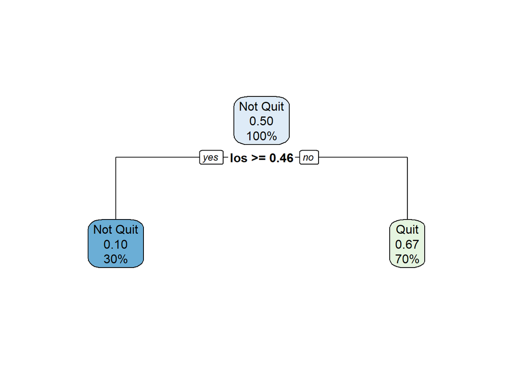

```r
## Create A Tree
rpart.plot::rpart.plot(x = cart_final$fit$fit$fit)
```

### (b)

The biggest weakness of this model is that I do not have data on the employees that did not leave for some reason, so there is no counter-factual to compare to. I also only have data for 2005-2009 which is highly limited. A better construction of the dependent variable of interest, as I discuss below, would benefit the accuracy and better capture the intention of the model. This can be remedied through the use of a larger source of data that includes bureaucrats who did not separate. Moving forward, I would want to predict quitting compared to continuing to work while the model now predicts quitting versus leaving for other reasons.

For feature engineering decisions, transforming some more variables during pre-processing may improve the accuracy and sensitivity of the model. Taking the log of salary could better account for outliers. Second, creating new variables from existing variables, like using pay-grade to classify an employee’s managerial status within the bureaucracy could prove to be a useful predictor. It is possible that higher level civil servants, who probably have greater exit options, may be more likely to quit. A categorical variable that captures different GS levels may increase the performance of this model.

For modeling decisions, I would first want to implement a random forest model. A random forest model, which can have better predictive power than a CART model, could increase the accuracy and recall of my model. I would also consider using a logistic regression model that could better predict the probability of quitting.

Finally, part of both feature selection and modeling decisions, defining my dependent variable as length of service before quitting, a continuous variable, would allow the use of non-classifications algorithms like linear regression models utilizing LASSO or Elastic-Net methods. This opens up the slate of models that I can use which could lead to different, and more accurate, results.